# Rapaort

Piotr Garsztka

18 stycznia 2017

# Spis treści

1. Wstęp
2. Opis danych
3. Wnioski
4. Wczytywanie i przetwarzanie danych
5. Podsumowanie rozmiaru zbioru i podstawowe statystyki
6. Analiza wartości atrybutów
7. Korelacje między zmiennymi
8. Interaktywny wykres
9. Regresor przewidujący rozmiar śledzia
10. Analiza ważności atrybutów

## Wstęp

Celem analizy jest określenie jakie mogą być główne przyczyny stopniowego zmniejszania się długości śledzi oceanicznych wyłowionych w Europie.

## Opis danych

Na przestrzeni ostatnich lat zauważono stopniowy spadek rozmiaru śledzia oceanicznego wyławianego w Europie. Do analizy zebrano pomiary śledzi i warunków w jakich żyją z ostatnich 60 lat. Dane były pobierane z połowów komercyjnych jednostek. W ramach połowu jednej jednostki losowo wybierano od 50 do 100 sztuk trzyletnich śledzi.

Kolumny w zbiorze danych oznaczają:

- **length**: długość złowionego śledzia [cm];
- **cfin1**: dostępność planktonu [zagęszczenie Calanus finmarchicus gat. 1];
- **cfin2**: dostępność planktonu [zagęszczenie Calanus finmarchicus gat. 2];
- **chel1**: dostępność planktonu [zagęszczenie Calanus helgolandicus gat. 1];
- **chel2**: dostępność planktonu [zagęszczenie Calanus helgolandicus gat. 2];
- **lcop1**: dostępność planktonu [zagęszczenie widłonogów gat. 1];
- **lcop2**: dostępność planktonu [zagęszczenie widłonogów gat. 2];
- **fbar**: natężenie połowów w regionie [ułamek pozostawionego narybku];
- **recr**: roczny narybek [liczba śledzi];
- **cumf**: łączne roczne natężenie połowów w regionie [ułamek pozostawionego narybku];
- **totaln**: łączna liczba ryb złowionych w ramach połowu [liczba śledzi];
- **sst**: temperatura przy powierzchni wody [°C];
- **sal**: poziom zasolenia wody [Knudsen ppt];
- **xmonth**: miesiąc połowu [numer miesiąca];
- **nao**: oscylacja północnoatlantycka [mb].

## Wnioski

Po przeprowadzeniu analizy zbioru danchy możemy stwierdzić że przyczyną zmniejszania się w od pewnego momętu rozmiaru śledzia jest zwiększona temperatura przy powierzchni wody.

## Wczytywanie i przetwarzanie danych

- Wykorzystane biblioteki.

```r
library(dplyr)
library(ggplot2)
library(corrplot)
library(plotly)
library(knitr)
library(rpart)
library(randomForest)
```

- Wczytywanie danych z pliku.

```r
#Wczytywanie danych z pliku.
dane <- read.csv("sledzie.csv",header = TRUE, sep = ",", dec = ".", na.strings = "?")

#Przykładowe dane.
knitr::kable(head(dane))
```

| X | length | cfin1 | cfin2 | chel1 | chel2 | lcop1 | lcop2 | fbar | recr | cumf | totaln | sst | sal | xmonth | nao |
| --- | --- | --- | --- | --- | --- | --- | --- | --- | --- | --- | --- | --- | --- | --- | --- |
| 0 | 23.0 | 0.02778 | 0.27785 | 2.46875 | NA | 2.54787 | 26.35881 | 0.356 | 482831 | 0.3059879 | 267380.8 | 14.30693 | 35.51234 | 7 | 2.8 |
| 1 | 22.5 | 0.02778 | 0.27785 | 2.46875 | 21.43548 | 2.54787 | 26.35881 | 0.356 | 482831 | 0.3059879 | 267380.8 | 14.30693 | 35.51234 | 7 | 2.8 |
| 2 | 25.0 | 0.02778 | 0.27785 | 2.46875 | 21.43548 | 2.54787 | 26.35881 | 0.356 | 482831 | 0.3059879 | 267380.8 | 14.30693 | 35.51234 | 7 | 2.8 |
| 3 | 25.5 | 0.02778 | 0.27785 | 2.46875 | 21.43548 | 2.54787 | 26.35881 | 0.356 | 482831 | 0.3059879 | 267380.8 | 14.30693 | 35.51234 | 7 | 2.8 |
| 4 | 24.0 | 0.02778 | 0.27785 | 2.46875 | 21.43548 | 2.54787 | 26.35881 | 0.356 | 482831 | 0.3059879 | 267380.8 | 14.30693 | 35.51234 | 7 | 2.8 |
| 5 | 22.0 | 0.02778 | 0.27785 | 2.46875 | 21.43548 | 2.54787 | NA | 0.356 | 482831 | 0.3059879 | 267380.8 | 14.30693 | 35.51234 | 7 | 2.8 |

- Przerwrzanie danych.

```r
#Występowanie brakujących danych.
sapply(dane, function(x) sum(is.na(x)))
```

```
##      X length  cfin1  cfin2  chel1  chel2  lcop1  lcop2   fbar   recr
##      0      0   1581   1536   1555   1556   1653   1591      0      0
##   cumf totaln    sst    sal xmonth    nao
##      0      0   1584      0      0      0
```

```r
#Usunięcie kolumny X.
dane_prz <- select(dane, length:nao)
head(dane_prz)
```

```
##   length   cfin1   cfin2   chel1    chel2   lcop1    lcop2  fbar   recr
## 1   23.0 0.02778 0.27785 2.46875       NA 2.54787 26.35881 0.356 482831
## 2   22.5 0.02778 0.27785 2.46875 21.43548 2.54787 26.35881 0.356 482831
## 3   25.0 0.02778 0.27785 2.46875 21.43548 2.54787 26.35881 0.356 482831
## 4   25.5 0.02778 0.27785 2.46875 21.43548 2.54787 26.35881 0.356 482831
## 5   24.0 0.02778 0.27785 2.46875 21.43548 2.54787 26.35881 0.356 482831
## 6   22.0 0.02778 0.27785 2.46875 21.43548 2.54787       NA 0.356 482831
##        cumf   totaln      sst      sal xmonth nao
## 1 0.3059879 267380.8 14.30693 35.51234      7 2.8
## 2 0.3059879 267380.8 14.30693 35.51234      7 2.8
## 3 0.3059879 267380.8 14.30693 35.51234      7 2.8
## 4 0.3059879 267380.8 14.30693 35.51234      7 2.8
## 5 0.3059879 267380.8 14.30693 35.51234      7 2.8
## 6 0.3059879 267380.8 14.30693 35.51234      7 2.8
```

```r
#Zastąpienie brakujących wartości średnia.
for(i in 1:ncol(dane_prz)){
  dane_prz[is.na(dane_prz[,i]), i] <- mean(dane_prz[,i], na.rm = TRUE)
}

#Sprawdzenie czy nadal występują brakujące wartości.
sapply(dane_prz, function(x) sum(is.na(x)))
```

```
## length  cfin1  cfin2  chel1  chel2  lcop1  lcop2   fbar   recr   cumf
##      0      0      0      0      0      0      0      0      0      0
## totaln    sst    sal xmonth    nao
##      0      0      0      0      0
```

```r
#Dane po przetworzeniu.
knitr::kable(head(dane_prz))
```

| length | cfin1 | cfin2 | chel1 | chel2 | lcop1 | lcop2 | fbar | recr | cumf | totaln | sst | sal | xmonth | nao |
| --- | --- | --- | --- | --- | --- | --- | --- | --- | --- | --- | --- | --- | --- | --- |
| 23.0 | 0.02778 | 0.27785 | 2.46875 | 21.22108 | 2.54787 | 26.35881 | 0.356 | 482831 | 0.3059879 | 267380.8 | 14.30693 | 35.51234 | 7 | 2.8 |
| 22.5 | 0.02778 | 0.27785 | 2.46875 | 21.43548 | 2.54787 | 26.35881 | 0.356 | 482831 | 0.3059879 | 267380.8 | 14.30693 | 35.51234 | 7 | 2.8 |
| 25.0 | 0.02778 | 0.27785 | 2.46875 | 21.43548 | 2.54787 | 26.35881 | 0.356 | 482831 | 0.3059879 | 267380.8 | 14.30693 | 35.51234 | 7 | 2.8 |
| 25.5 | 0.02778 | 0.27785 | 2.46875 | 21.43548 | 2.54787 | 26.35881 | 0.356 | 482831 | 0.3059879 | 267380.8 | 14.30693 | 35.51234 | 7 | 2.8 |
| 24.0 | 0.02778 | 0.27785 | 2.46875 | 21.43548 | 2.54787 | 26.35881 | 0.356 | 482831 | 0.3059879 | 267380.8 | 14.30693 | 35.51234 | 7 | 2.8 |
| 22.0 | 0.02778 | 0.27785 | 2.46875 | 21.43548 | 2.54787 | 28.41883 | 0.356 | 482831 | 0.3059879 | 267380.8 | 14.30693 | 35.51234 | 7 | 2.8 |

## Podsumowanie rozmiaru zbioru i podstawowe statystyki

- Podstawowe dane.

```
## 'data.frame':    52582 obs. of  15 variables:
##  $ length: num  23 22.5 25 25.5 24 22 24 23.5 22.5 22.5 ...
##  $ cfin1 : num  0.0278 0.0278 0.0278 0.0278 0.0278 ...
##  $ cfin2 : num  0.278 0.278 0.278 0.278 0.278 ...
##  $ chel1 : num  2.47 2.47 2.47 2.47 2.47 ...
##  $ chel2 : num  21.2 21.4 21.4 21.4 21.4 ...
##  $ lcop1 : num  2.55 2.55 2.55 2.55 2.55 ...
##  $ lcop2 : num  26.4 26.4 26.4 26.4 26.4 ...
##  $ fbar  : num  0.356 0.356 0.356 0.356 0.356 0.356 0.356 0.356 0.356 0.356 ...
##  $ recr  : num  482831 482831 482831 482831 482831 ...
##  $ cumf  : num  0.306 0.306 0.306 0.306 0.306 ...
##  $ totaln: num  267381 267381 267381 267381 267381 ...
##  $ sst   : num  14.3 14.3 14.3 14.3 14.3 ...
##  $ sal   : num  35.5 35.5 35.5 35.5 35.5 ...
##  $ xmonth: num  7 7 7 7 7 7 7 7 7 7 ...
##  $ nao   : num  2.8 2.8 2.8 2.8 2.8 2.8 2.8 2.8 2.8 2.8 ...
```

- Podstawowe statystyki.

```
##      length         cfin1             cfin2             chel1
##  Min.   :19.0   Min.   : 0.0000   Min.   : 0.0000   Min.   : 0.000
##  1st Qu.:24.0   1st Qu.: 0.0000   1st Qu.: 0.2778   1st Qu.: 2.469
##  Median :25.5   Median : 0.1333   Median : 0.7012   Median : 6.083
##  Mean   :25.3   Mean   : 0.4458   Mean   : 2.0248   Mean   :10.006
##  3rd Qu.:26.5   3rd Qu.: 0.3603   3rd Qu.: 1.9973   3rd Qu.:11.500
##  Max.   :32.5   Max.   :37.6667   Max.   :19.3958   Max.   :75.000
##      chel2            lcop1              lcop2             fbar
##  Min.   : 5.238   Min.   :  0.3074   Min.   : 7.849   Min.   :0.0680
##  1st Qu.:13.589   1st Qu.:  2.5479   1st Qu.:17.808   1st Qu.:0.2270
##  Median :21.435   Median :  7.1229   Median :25.338   Median :0.3320
##  Mean   :21.221   Mean   : 12.8108   Mean   :28.419   Mean   :0.3304
##  3rd Qu.:27.193   3rd Qu.: 21.2315   3rd Qu.:37.232   3rd Qu.:0.4560
##  Max.   :57.706   Max.   :115.5833   Max.   :68.736   Max.   :0.8490
##       recr              cumf             totaln             sst
##  Min.   : 140515   Min.   :0.06833   Min.   : 144137   Min.   :12.77
##  1st Qu.: 360061   1st Qu.:0.14809   1st Qu.: 306068   1st Qu.:13.63
##  Median : 421391   Median :0.23191   Median : 539558   Median :13.86
##  Mean   : 520367   Mean   :0.22981   Mean   : 514973   Mean   :13.87
##  3rd Qu.: 724151   3rd Qu.:0.29803   3rd Qu.: 730351   3rd Qu.:14.16
##  Max.   :1565890   Max.   :0.39801   Max.   :1015595   Max.   :14.73
##       sal            xmonth            nao
##  Min.   :35.40   Min.   : 1.000   Min.   :-4.89000
##  1st Qu.:35.51   1st Qu.: 5.000   1st Qu.:-1.89000
##  Median :35.51   Median : 8.000   Median : 0.20000
##  Mean   :35.51   Mean   : 7.258   Mean   :-0.09236
##  3rd Qu.:35.52   3rd Qu.: 9.000   3rd Qu.: 1.63000
##  Max.   :35.61   Max.   :12.000   Max.   : 5.08000
```

## Analiza wartości atrybutów

- Długość złowionego śledzia [cm];

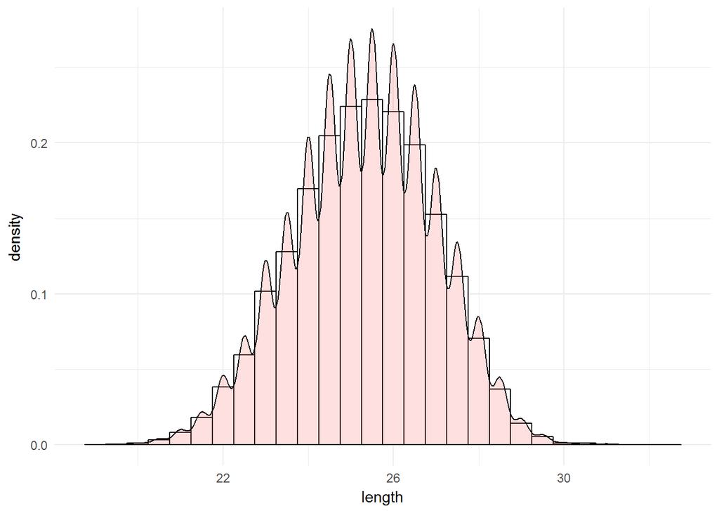

- Dostępność planktonu [zagęszczenie Calanus finmarchicus gat. 1];

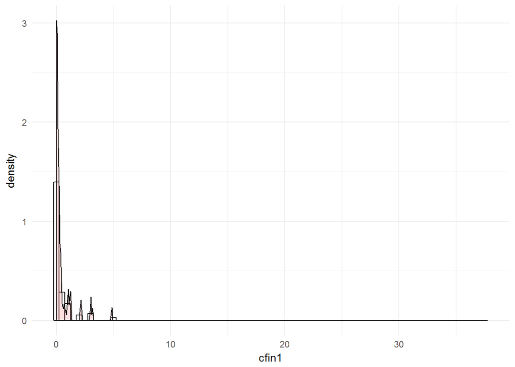

- Dostępność planktonu [zagęszczenie Calanus finmarchicus gat. 2];

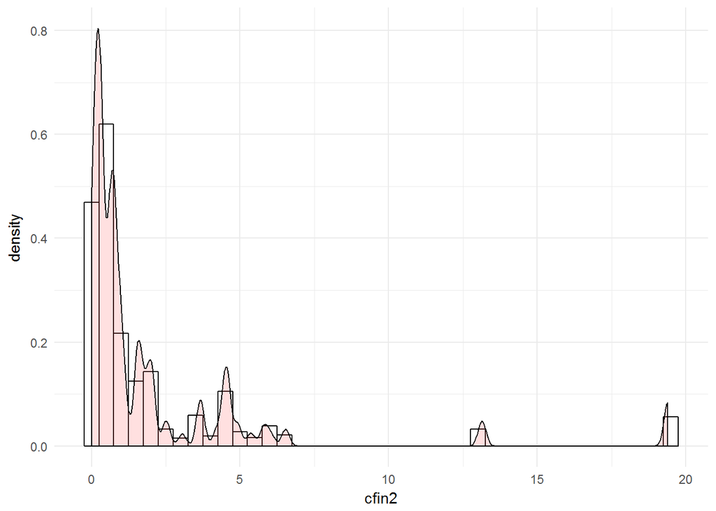

- Dostępność planktonu [zagęszczenie Calanus helgolandicus gat. 1];

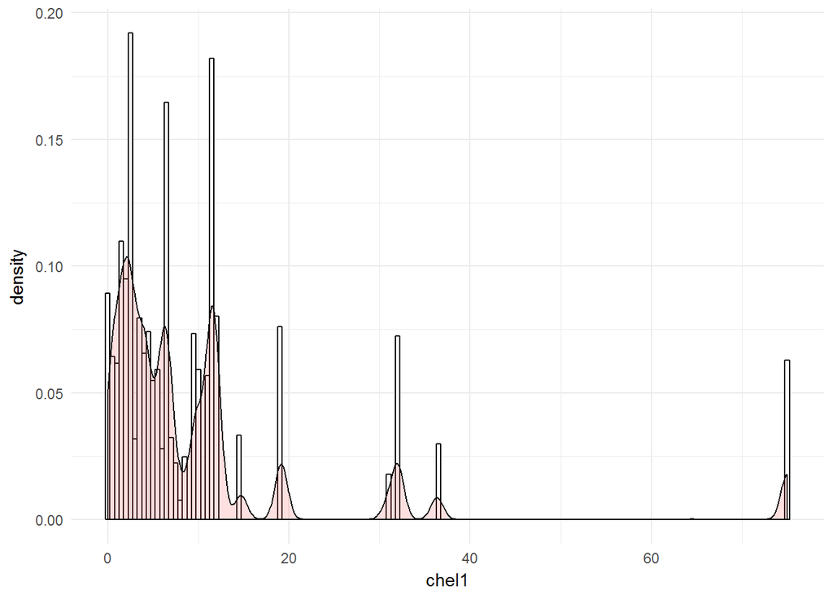

- Dostępność planktonu [zagęszczenie Calanus helgolandicus gat. 2];

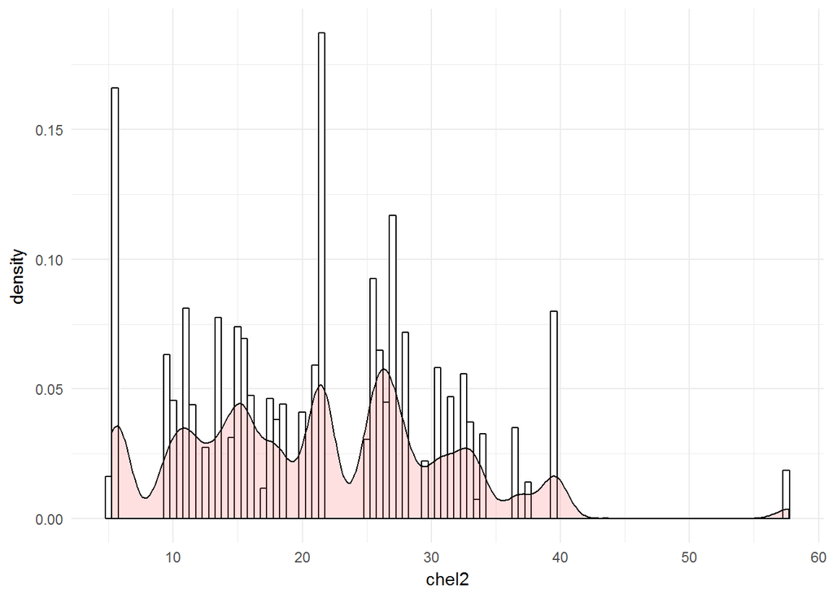

- Dostępność planktonu [zagęszczenie widłonogów gat. 1];

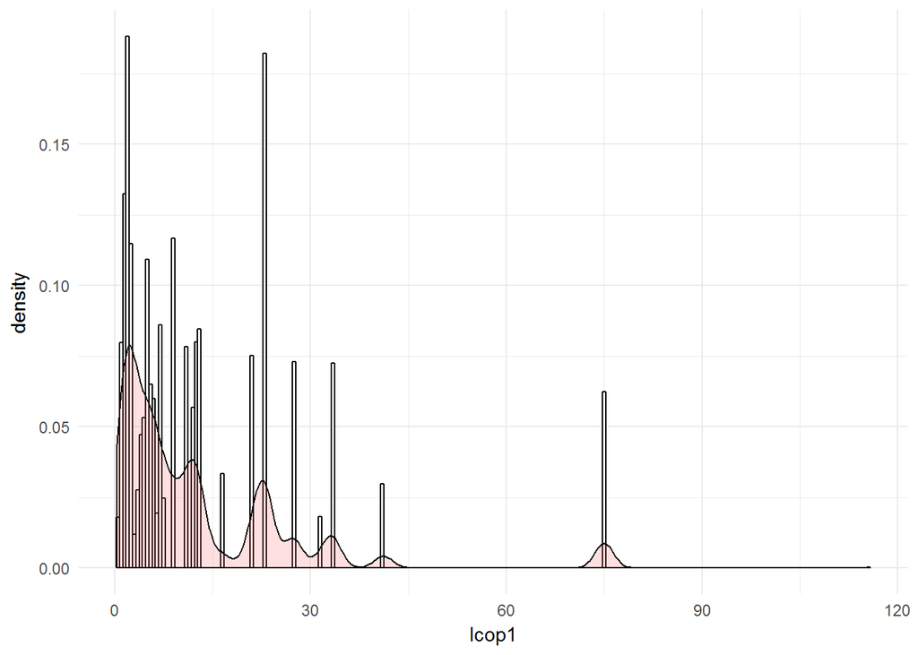

- Dostępność planktonu [zagęszczenie widłonogów gat. 2];

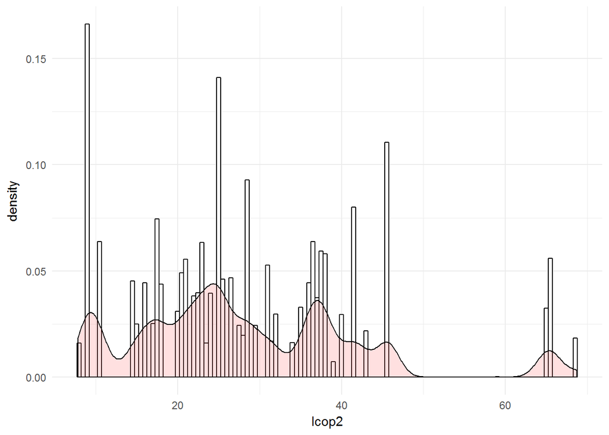

- Natężenie połowów w regionie [ułamek pozostawionego narybku];

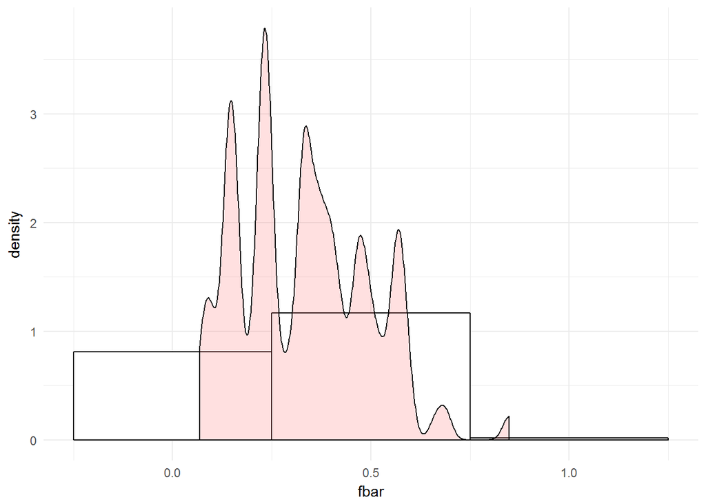

- Roczny narybek [liczba śledzi];

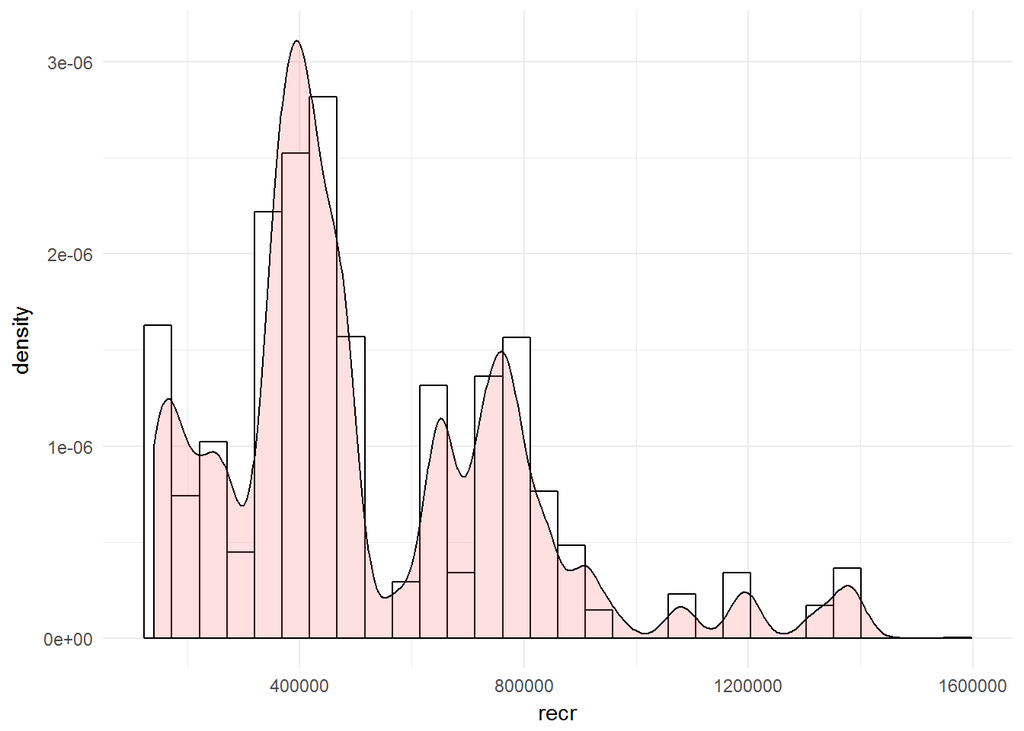

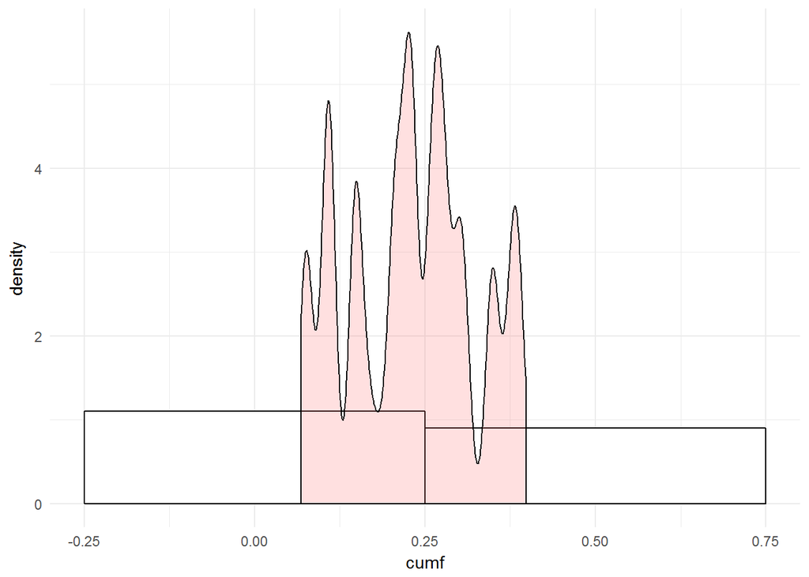

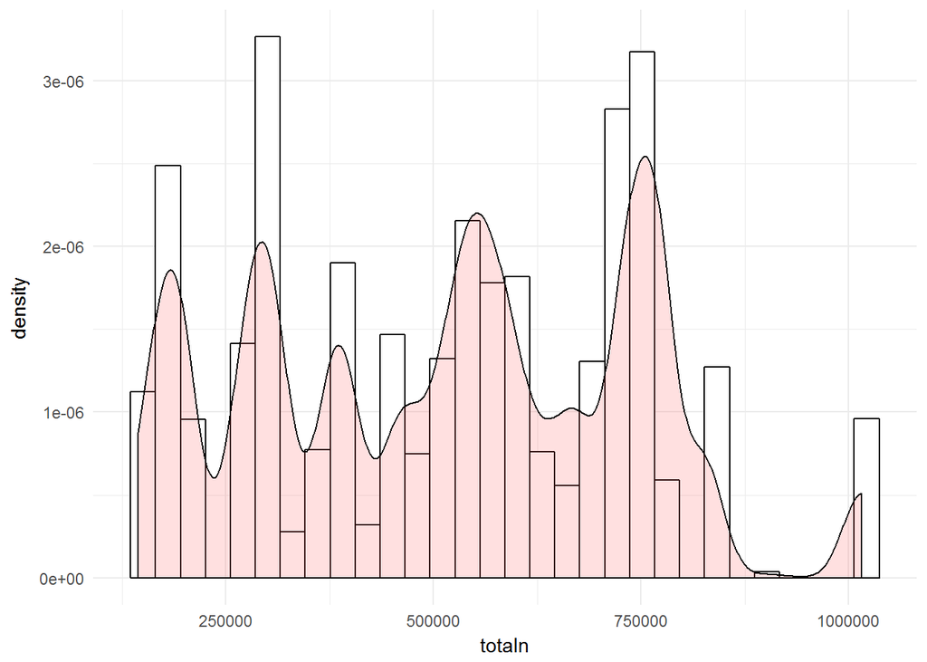

- Temperatura przy powierzchni wody [°C];

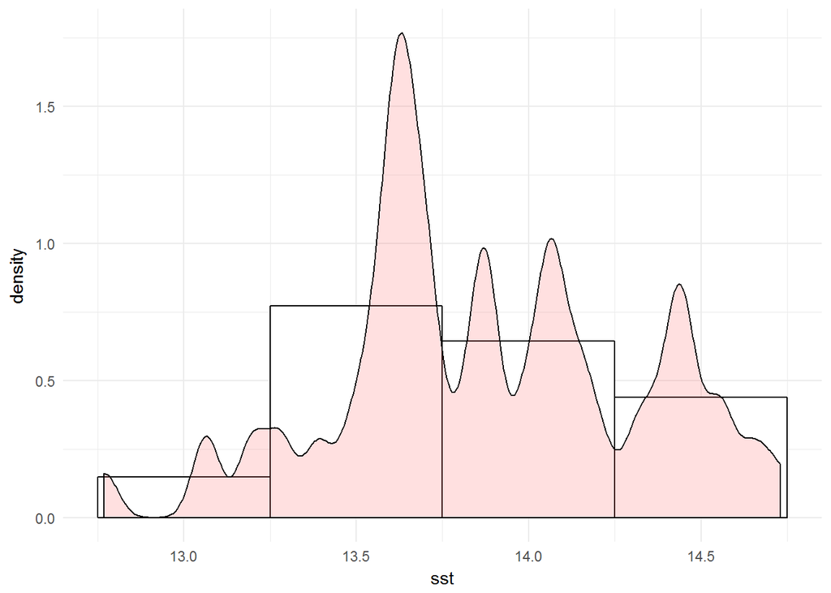

- Poziom zasolenia wody [Knudsen ppt];

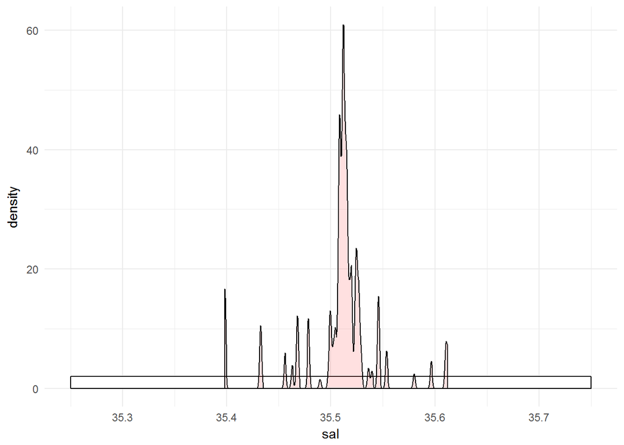

- Miesiąc połowu [numer miesiąca];

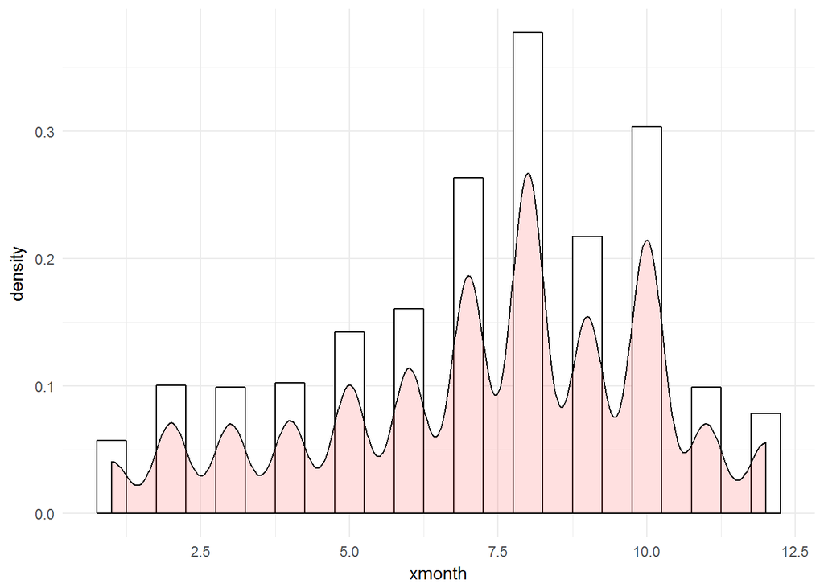

- Oscylacja północnoatlantycka [mb].

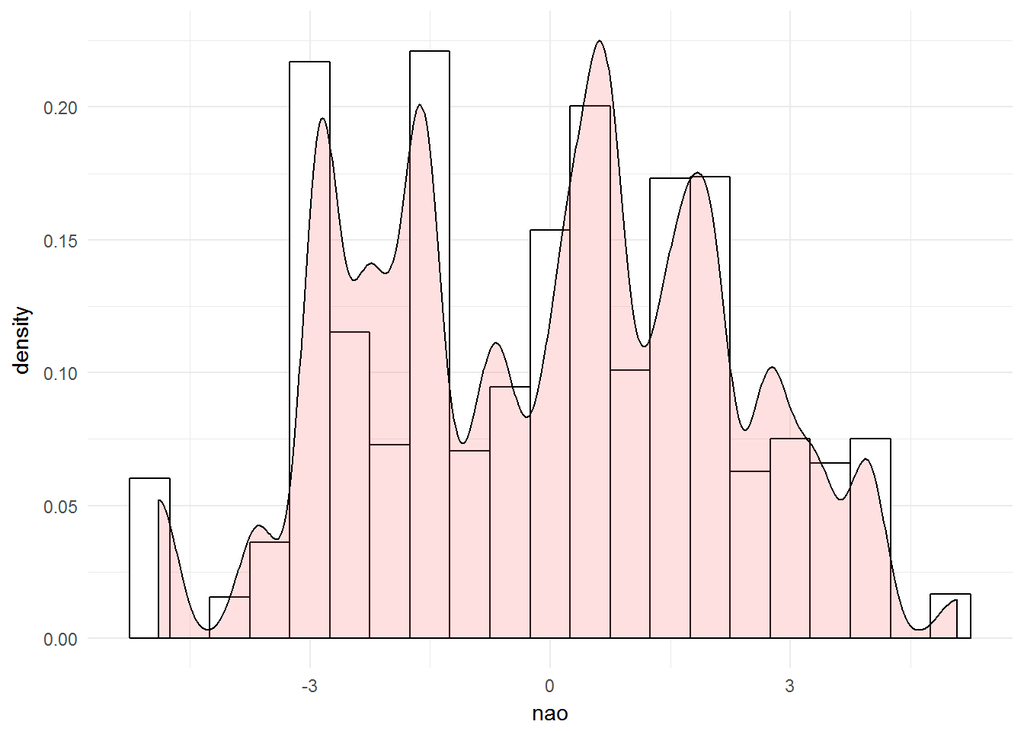

## Korelacje między zmiennymi

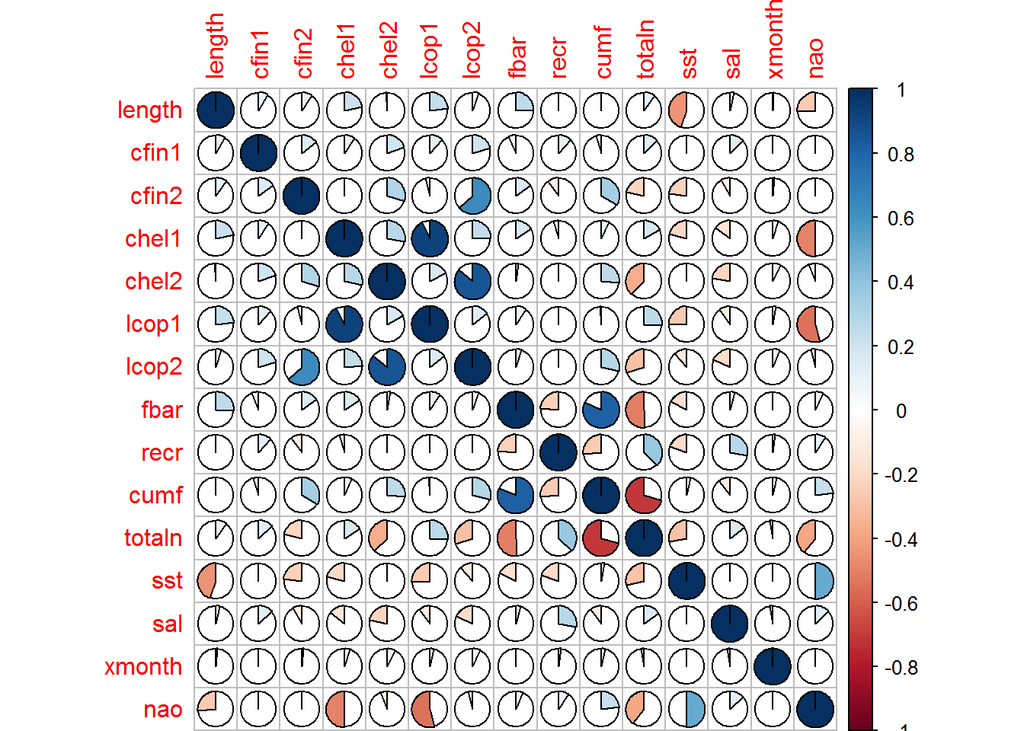

## Interaktywny wykres

[interactive chart not shown]

## Regresor przewidujący rozmiar śledzia

```r
#R^2
a <- lm(length ~ ., data = dane_prz)
summary(a)$r.squared
```

```
## [1] 0.3164881
```

```r
#RMSE
rmse <- function(error)
{
    sqrt(mean(error^2))
}

rmse(a$residuals)
```

```
## [1] 1.366484
```

```r
# grow tree
fit <- rpart(length ~ ., data = dane_prz, method = "anova")

printcp(fit) # display the results
```

```
##
## Regression tree:
## rpart(formula = length ~ ., data = dane_prz, method = "anova")
##
## Variables actually used in tree construction:
## [1] cfin2 lcop1 lcop2 recr  sst
##
## Root node error: 143648/52582 = 2.7319
##
## n= 52582
##
##         CP nsplit rel error  xerror      xstd
## 1 0.248756      0   1.00000 1.00004 0.0058280
## 2 0.075430      1   0.75124 0.75134 0.0045482
## 3 0.036726      2   0.67581 0.67593 0.0042905
## 4 0.035314      3   0.63909 0.64117 0.0041335
## 5 0.018808      4   0.60377 0.60587 0.0039828
## 6 0.010000      5   0.58497 0.58526 0.0038884
```

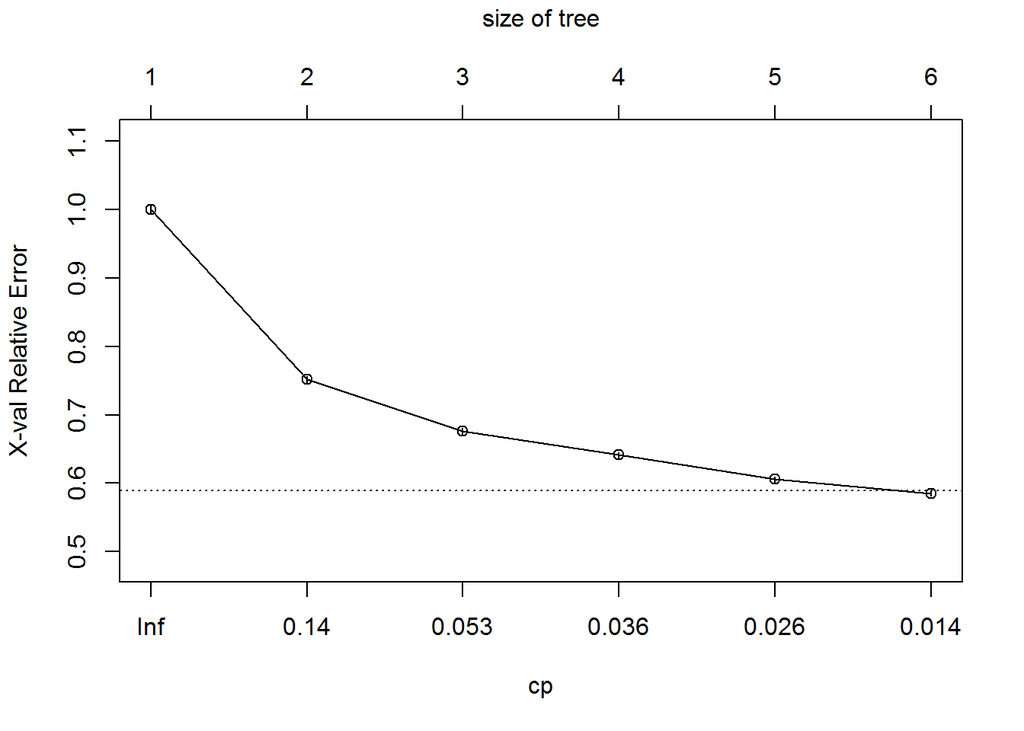

```r
plotcp(fit) # visualize cross-validation results
```

```r
summary(fit) # detailed summary of splits
```

```
## Call:
## rpart(formula = length ~ ., data = dane_prz, method = "anova")
##   n= 52582
##
##           CP nsplit rel error    xerror        xstd
## 1 0.24875642      0 1.0000000 1.0000367 0.005827959
## 2 0.07542966      1 0.7512436 0.7513391 0.004548236
## 3 0.03672634      2 0.6758139 0.6759336 0.004290451
## 4 0.03531406      3 0.6390876 0.6411681 0.004133488
## 5 0.01880835      4 0.6037735 0.6058682 0.003982760
## 6 0.01000000      5 0.5849652 0.5852649 0.003888358
##
## Variable importance
##    sst totaln   fbar    sal   recr  chel2  lcop1    nao  lcop2  chel1
##     26     13     12     10      7      6      5      5      5      4
##   cumf  cfin2
##      4      3
##
## Node number 1: 52582 observations,    complexity param=0.2487564
##   mean=25.30436, MSE=2.731888
##   left son=2 (15191 obs) right son=3 (37391 obs)
##   Primary splits:
##       sst   < 14.10273   to the right, improve=0.24875640, (0 missing)
##       fbar  < 0.1395     to the left,  improve=0.10604880, (0 missing)
##       nao   < -0.855     to the right, improve=0.08071659, (0 missing)
##       lcop1 < 25.16666   to the left,  improve=0.08014126, (0 missing)
##       recr  < 339431.5   to the right, improve=0.06747398, (0 missing)
##   Surrogate splits:
##       fbar   < 0.1395     to the left,  agree=0.820, adj=0.379, (0 split)
##       sal    < 35.45936   to the left,  agree=0.786, adj=0.259, (0 split)
##       totaln < 379691.5   to the left,  agree=0.759, adj=0.166, (0 split)
##       nao    < 3.69       to the right, agree=0.754, adj=0.150, (0 split)
##       cumf   < 0.1051474  to the left,  agree=0.744, adj=0.115, (0 split)
##
## Node number 2: 15191 observations,    complexity param=0.03672634
##   mean=24.01103, MSE=1.996603
##   left son=4 (8444 obs) right son=5 (6747 obs)
##   Primary splits:
##       lcop2  < 24.86266   to the right, improve=0.1739400, (0 missing)
##       totaln < 306672     to the left,  improve=0.1735618, (0 missing)
```

[output cut: 60 more lines]

```
##
## Node number 7: 7842 observations
##   mean=26.87475, MSE=1.676101
##
## Node number 10: 2040 observations
##   mean=23.70907, MSE=1.18558
##
## Node number 11: 4707 observations
##   mean=25.08689, MSE=1.412569
##
## Node number 12: 24497 observations
##   mean=25.36432, MSE=1.695196
##
## Node number 13: 5052 observations
##   mean=26.46487, MSE=1.386582
```

```
##
## Regression tree:
## rpart(formula = length ~ ., data = dane_prz, method = "anova")
##
## Variables actually used in tree construction:
## [1] cfin2 lcop1 lcop2 recr  sst
##
## Root node error: 143648/52582 = 2.7319
##
## n= 52582
##
##         CP nsplit rel error  xerror      xstd
## 1 0.248756      0   1.00000 1.00004 0.0058280
## 2 0.075430      1   0.75124 0.75134 0.0045482
## 3 0.036726      2   0.67581 0.67593 0.0042905
## 4 0.035314      3   0.63909 0.64117 0.0041335
## 5 0.018808      4   0.60377 0.60587 0.0039828
## 6 0.010000      5   0.58497 0.58526 0.0038884
```

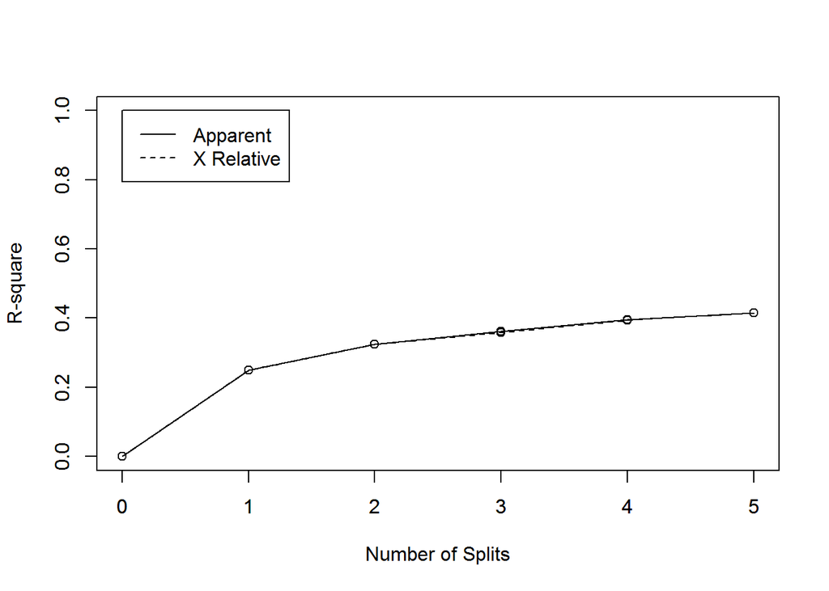

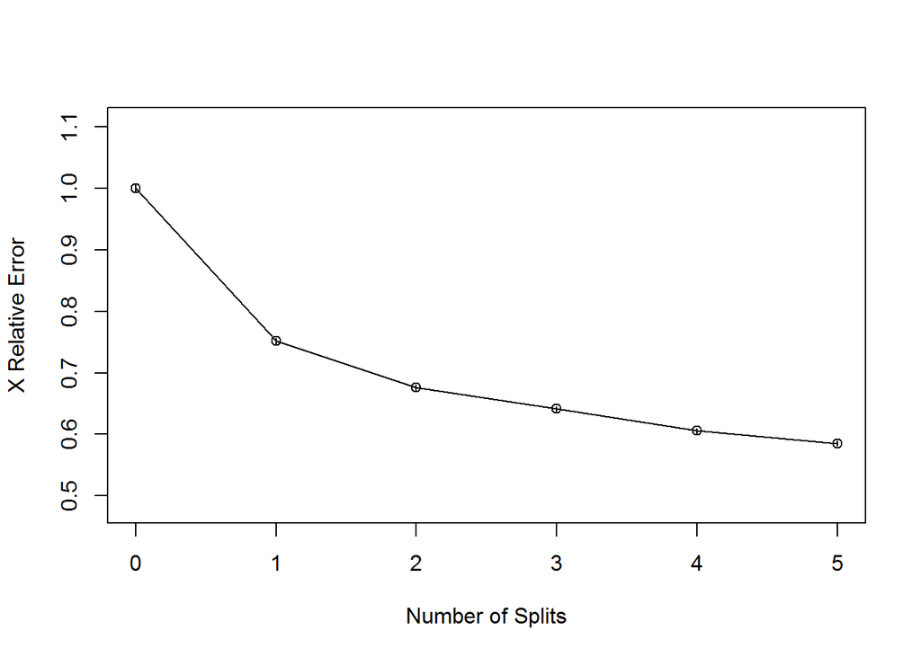

```r
# create additional plots
par(mfrow=c(1,1)) # two plots on one page
rsq.rpart(fit) # visualize cross-validation results
```

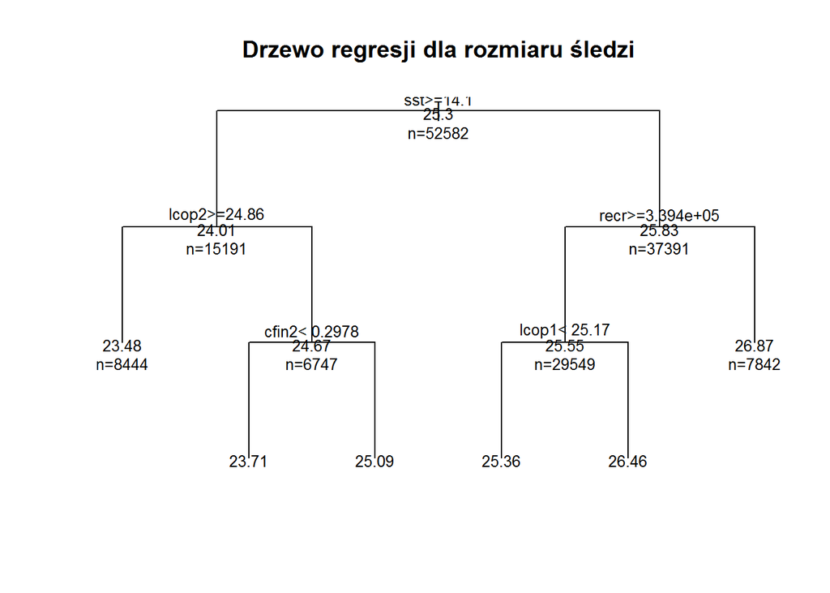

```r
# plot tree
plot(fit, uniform=TRUE, main = "Drzewo regresji dla rozmiaru śledzi")
text(fit, use.n=TRUE, all=TRUE, cex = .8)
```

## Analiza ważności atrybutów

```r
fit2 <- randomForest(length ~ ., data = dane_prz)
print(fit2) # view results
```

```
##
## Call:
##  randomForest(formula = length ~ ., data = dane_prz)
##                Type of random forest: regression
##                      Number of trees: 500
## No. of variables tried at each split: 4
##
##           Mean of squared residuals: 1.314249
##                     % Var explained: 51.89
```

```r
importance(fit2) # importance of each predictor
```

```
##        IncNodePurity
## cfin1       2817.393
## cfin2       2950.724
## chel1       2261.004
## chel2       2941.703
## lcop1       5000.667
## lcop2       2259.364
## fbar        7641.782
## recr        5984.803
## cumf        2579.924
## totaln      8635.996
## sst        22444.332
## sal         3419.286
## xmonth      5111.755
## nao         3999.566
```